# Simular variables aleatorias

Diplomado en Análisis de datos con R para la acuicultura

Dr. José A. Gallardo y Dra. María Angélica Rueda.

Pontificia Universidad Católica de Valparaíso  
jose.gallardo@pucv.cl

19 June 2021

## Introducción

En el siguiente proyecto se simulan diversos set de datos y figuras con el propósito de ser utilizados en la enseñanza del Anális de datos con R aplicado a la acuicultura.

## Índice

1. Distribución media muestral: caso 1
2. Distribución media muestral: caso 2
3. ANOVA 1 vía: Peso ~ cepas (Tilapia)
4. Correlación entre dos variables: N = 50.000
5. Correlación Peso WFE y color filete (Salmón)
6. Análisis de sobrevivencia con y sin antibióticos (Trucha)
7. Regresión lineal simple: peso ~ genotipos (Salmon)
8. Regresión lineal múltiple: ejemplo para clase
9. Regresión lineal múltiple: ejercicio guía

## Distribución media muestral: caso 1

Adaptado de: © 2016 Angelo Santana & Carmen N. Hernández, Departamento de Matemáticas, ULPGC

Variable: Peso del cuerpo pez

Objetivo: No rechaza prueba de hipótesis

**H<sub>0</sub>**: El peso medio de sus peces es igual a 1 Kg.

Si **$\bar{X}$** = 1,1 Kg, rechaza la hipótesis?

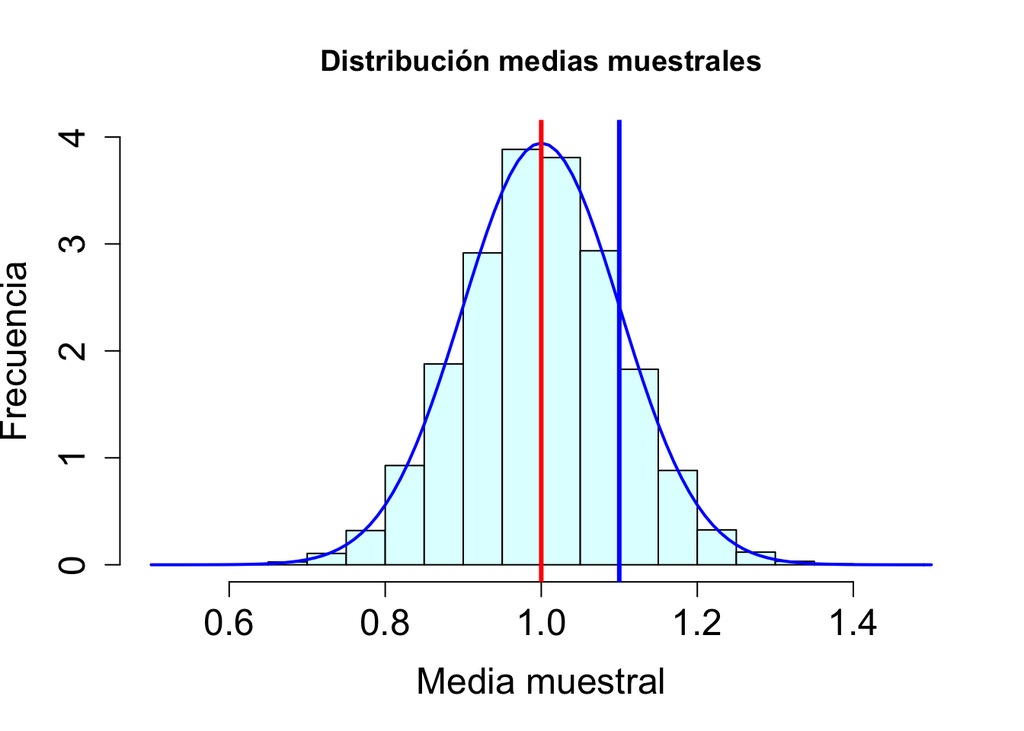

## Distribución media muestral: caso 2

Adaptado de: © 2016 Angelo Santana & Carmen N. Hernández, Departamento de Matemáticas, ULPGC

Variable: Peso del cuerpo pez

Objetivo: Rechaza prueba de hipótesis

**H<sub>0</sub>**: El peso medio de sus peces es igual a 1 Kg.

Si **$\bar{X}$** = 1,2 Kg, rechaza la hipótesis?

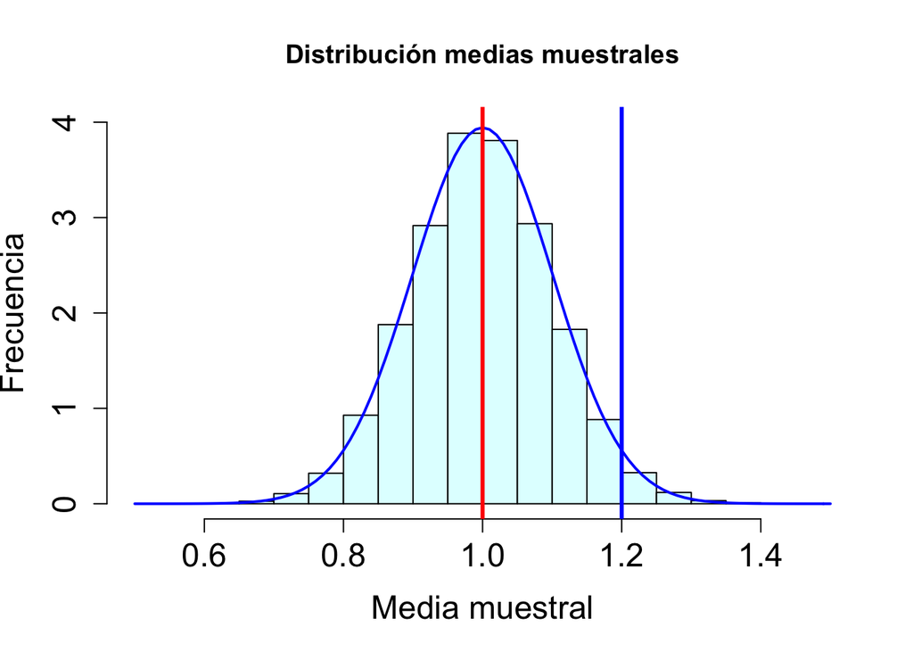

## ANOVA 1 vía: Peso ~ cepas (Tilapia)

```r
tilapia_cepas <- PlantGrowth
names(tilapia_cepas) <- c("Peso", "Cepa")
tilapia_cepas$Cepa <- factor(tilapia_cepas$Cepa,
                             labels = c("Cepa 1", "Cepa2", "Cepa 3"))

# Exporta datos simulados tilapia_cepas
# a) Guarda el directorio actual
old_wd <- getwd()

# b) Va al directorio Datos_simulados
setwd(paste0(getwd(),"/Datos_simulados"))

write.csv(tilapia_cepas, file = "tilapia_cepas.csv")

# c) Vuele al directorio principal
setwd(old_wd)
```

## Correlación entre dos variables: N = 50.000

Variable: Dos variables estandarizadas X e Y

Objetivo: Demostrar que al aumentar el N se puede rechazar una hipotesis nula de correlación, aun cuando esta seá muy pequeña 0,01.

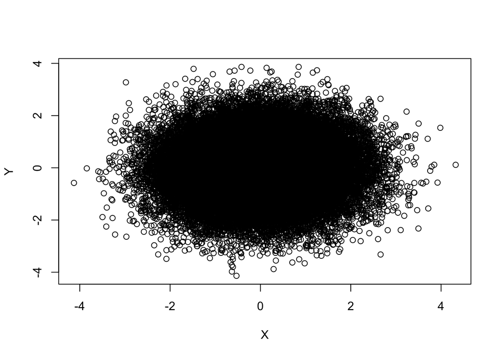

```
##
##  Pearson's product-moment correlation
##
## data:  dat$X and dat$Y
## t = 2.3455, df = 49998, p-value = 0.01901
## alternative hypothesis: true correlation is not equal to 0
## 95 percent confidence interval:
##  0.001723728 0.019252328
## sample estimates:
##        cor
## 0.01048883
```

## Correlación Peso WFE y color filete salmón del Atlántico

```r
args(mvrnorm)
```

```
## function (n = 1, mu, Sigma, tol = 1e-06, empirical = FALSE, EISPACK = FALSE)
## NULL
```

```r
# Simulated Correlation between Body Weight, Color phenotypes in Atlantic salmon
# Generate a set of means and a symmetric covariance matrix
means   <- c(5500, 25)
cov.mat <- matrix(c(800000, -300, -300, 4), nrow = 2, ncol = 2)
WFE.COLOR <- data.frame(mvrnorm(949, means, cov.mat))
# Give the data fram column headings
names(WFE.COLOR) <- c("Weight", 'Color')
WFE.COLOR[1:10, ]
```

```
##      Weight    Color
## 1  5262.984 28.35527
## 2  3862.529 23.79745
## 3  5553.110 25.95218
## 4  5547.591 23.00347
## 5  5108.327 25.89661
## 6  4303.749 25.76573
## 7  5431.407 25.19421
## 8  5092.970 25.32153
## 9  4718.386 26.23714
## 10 7739.115 25.31876
```

```r
# Look at the mean and covariance to check the function
colMeans(WFE.COLOR)
```

```
##     Weight      Color
## 5483.14396   25.01462
```

```r
cov(WFE.COLOR)
```

```
##             Weight       Color
## Weight 844929.2870 -312.718761
## Color    -312.7188    3.925308
```

```r
cov(WFE.COLOR$Weight, WFE.COLOR$Color)
```

```
## [1] -312.7188
```

```r
cor(WFE.COLOR$Weight, WFE.COLOR$Color)
```

```
## [1] -0.1717145
```

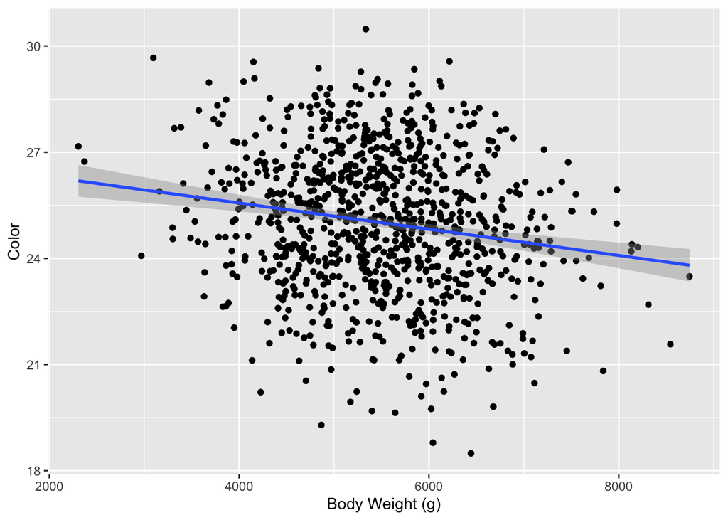

```r
# Plot and export the joint distribution of the variables
p <- ggplot(WFE.COLOR, aes(x = Weight, y = Color))
p + geom_point() + geom_smooth(method = "lm") +
  xlab("Body Weight (g)") + ylab("Color")
```

```r
# Exporta datos simulados cor_wfe_color
# a) Guarda el directorio actual
old_wd <- getwd()

# b) Va al directorio Datos_simulados
setwd(paste0(getwd(),"/Datos_simulados"))

write.table(WFE.COLOR, file = "cor_wfe_color.csv", sep = ",", dec = ",")

# c) Vuele al directorio principal
setwd(old_wd)
```

## Análisis de sobrevivencia con y sin antibióticos

```r
library(readxl)
library(survival)
library(survminer)
larv <- read_excel("surv_dat.xlsx", sheet = 1)
summary(larv)
```

```
##   sample_id         antibiotico            stime           status
##  Length:16          Length:16          Min.   :10.00   Min.   :0.0000
##  Class :character   Class :character   1st Qu.:37.50   1st Qu.:0.0000
##  Mode  :character   Mode  :character   Median :45.00   Median :0.0000
##                                        Mean   :43.12   Mean   :0.4375
##                                        3rd Qu.:60.00   3rd Qu.:1.0000
##                                        Max.   :60.00   Max.   :1.0000
```

```r
larv$antibiotico <- as.factor(larv$antibiotico)
str(larv)
```

```
## tibble [16 × 4] (S3: tbl_df/tbl/data.frame)
##  $ sample_id  : chr [1:16] "s1" "s2" "s3" "s4" ...
##  $ antibiotico: Factor w/ 2 levels "no","si": 1 1 1 1 1 1 1 1 2 2 ...
##  $ stime      : num [1:16] 10 10 10 30 40 40 40 60 40 50 ...
##  $ status     : num [1:16] 1 1 1 1 1 0 0 0 1 1 ...
```

```r
larv_fit <- survfit(Surv(stime,status)~strata(antibiotico),
             data = larv, na.action=na.exclude, type="kaplan-meier")

summary(larv_fit)
```

```
## Call: survfit(formula = Surv(stime, status) ~ strata(antibiotico),
##     data = larv, na.action = na.exclude, type = "kaplan-meier")
##
##                 strata(antibiotico)=no
##  time n.risk n.event survival std.err lower 95% CI upper 95% CI
##    10      8       3    0.625   0.171        0.365        1.000
##    30      5       1    0.500   0.177        0.250        1.000
##    40      4       1    0.375   0.171        0.153        0.917
##
##                 strata(antibiotico)=si
##  time n.risk n.event survival std.err lower 95% CI upper 95% CI
##    40      8       1    0.875   0.117        0.673            1
##    50      7       1    0.750   0.153        0.503            1
```

```r
surv_diff <- survdiff(Surv(stime,status)~antibiotico, data = larv)
surv_diff
```

```
## Call:
## survdiff(formula = Surv(stime, status) ~ antibiotico, data = larv)
##
##                N Observed Expected (O-E)^2/E (O-E)^2/V
## antibiotico=no 8        5     2.68      2.02      3.86
## antibiotico=si 8        2     4.32      1.25      3.86
##
##  Chisq= 3.9  on 1 degrees of freedom, p= 0.05
```

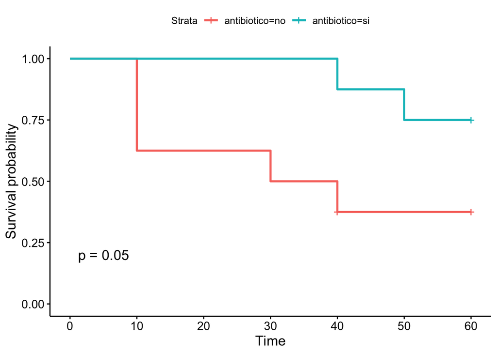

```r
ggsurvplot(survfit(Surv(stime,status) ~ antibiotico, data = larv, na.action = na.exclude, type="kaplan-meier"),
pval = TRUE, conf.int = FALSE)
```

## Regresión lineal simple: peso ~ genotipos (Salmon)

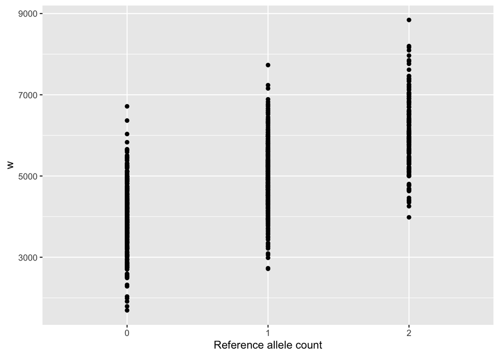

```r
# We can use rnorm to simulate a phenotype and QTL data
w.means <- c(4000, 5000, 6000) # Complete dominance
w.sd    <- 800
# Generate a SNP. AF 0.4
help(rbinom)
snp     <- rbinom(1000, 2, 0.4) # n (POPULATION), size (2 ALELLES) and prob (FREQUENCY LOWER ALLELE)
# Generate PHENO given the GENO and bind to data frame
w        <- rnorm(1000, w.means[factor(snp)], w.sd)
snp.data <- data.frame(cbind(w, snp))

# Exporta datos simulados snp.data
# a) Guarda el directorio actual
old_wd <- getwd()

# b) Va al directorio Datos_simulados
setwd(paste0(getwd(),"/Datos_simulados"))

write.table(snp.data, file = "snp.data.csv", sep = ";", dec = ",")

# c) Vuele al directorio principal
setwd(old_wd)

# Plot the phenotype as a funtion of genotupe
library(ggplot2)
p <- ggplot(snp.data, aes(x = factor(snp), y = w))
p + geom_point() + xlab("Reference allele count")
```

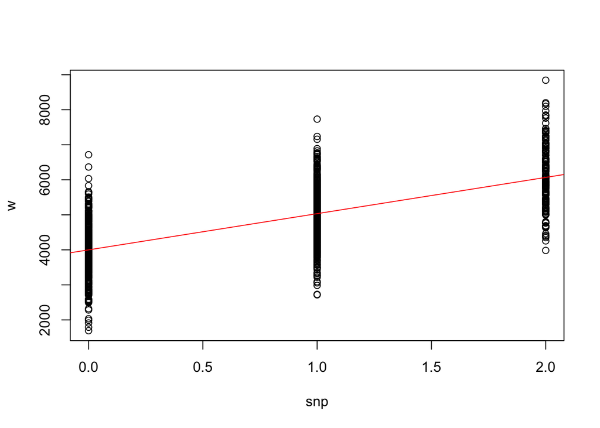

```r
# Lineal model
par(mfrow=c(1,1))
lm.qtl <- lm(w ~ -1 + factor(snp))
plot(snp,w,main="") #inspeccion visual
abline(lm(w~snp), cex=0.9, col="red")
```

```r
anova(lm.qtl)
```

```
## Analysis of Variance Table
##
## Response: w
##              Df     Sum Sq    Mean Sq F value    Pr(>F)
## factor(snp)   3 2.3898e+10 7966155183   12021 < 2.2e-16 ***
## Residuals   997 6.6068e+08     662671
## ---
## Signif. codes:  0 '***' 0.001 '**' 0.01 '*' 0.05 '.' 0.1 ' ' 1
```

```r
summary(lm.qtl)
```

```
##
## Call:
## lm(formula = w ~ -1 + factor(snp))
##
## Residuals:
##      Min       1Q   Median       3Q      Max
## -2313.61  -522.37   -20.67   536.24  2767.98
##
## Coefficients:
##              Estimate Std. Error t value Pr(>|t|)
## factor(snp)0  4002.51      43.39   92.25   <2e-16 ***
## factor(snp)1  5029.13      36.89  136.34   <2e-16 ***
## factor(snp)2  6075.17      64.16   94.69   <2e-16 ***
## ---
## Signif. codes:  0 '***' 0.001 '**' 0.01 '*' 0.05 '.' 0.1 ' ' 1
##
## Residual standard error: 814 on 997 degrees of freedom
## Multiple R-squared:  0.9731, Adjusted R-squared:  0.973
## F-statistic: 1.202e+04 on 3 and 997 DF,  p-value: < 2.2e-16
```

## Regresión lineal múltiple: ejemplo para clase.

```r
set.seed(50)
X1=rnorm(100,0,1)
X2=rnorm(100,0,1)+(3.1*X1)
Y= 2 + 0.5 * X1 + 0.1 * X2 + rnorm(100,0,0.4)
lm1<- lm(Y~X1+X2)
lm2<- lm(Y~X1)
summary(lm1)
```

```
##
## Call:
## lm(formula = Y ~ X1 + X2)
##
## Residuals:
##      Min       1Q   Median       3Q      Max
## -1.09720 -0.27163  0.04586  0.29220  0.72779
##
## Coefficients:
##             Estimate Std. Error t value Pr(>|t|)
## (Intercept)  2.05696    0.04044  50.865  < 2e-16 ***
## X1           0.53563    0.13172   4.067 9.71e-05 ***
## X2           0.07307    0.04087   1.788   0.0769 .
## ---
## Signif. codes:  0 '***' 0.001 '**' 0.01 '*' 0.05 '.' 0.1 ' ' 1
##
## Residual standard error: 0.3995 on 97 degrees of freedom
## Multiple R-squared:  0.7859, Adjusted R-squared:  0.7815
## F-statistic:   178 on 2 and 97 DF,  p-value: < 2.2e-16
```

```r
summary(lm2)
```

```
##
## Call:
## lm(formula = Y ~ X1)
##
## Residuals:
##      Min       1Q   Median       3Q      Max
## -1.10803 -0.24008  0.05222  0.26130  0.75213
##
## Coefficients:
##             Estimate Std. Error t value Pr(>|t|)
## (Intercept)  2.04930    0.04066   50.40   <2e-16 ***
## X1           0.75974    0.04090   18.58   <2e-16 ***
## ---
## Signif. codes:  0 '***' 0.001 '**' 0.01 '*' 0.05 '.' 0.1 ' ' 1
##
## Residual standard error: 0.4039 on 98 degrees of freedom
## Multiple R-squared:  0.7788, Adjusted R-squared:  0.7766
## F-statistic: 345.1 on 1 and 98 DF,  p-value: < 2.2e-16
```

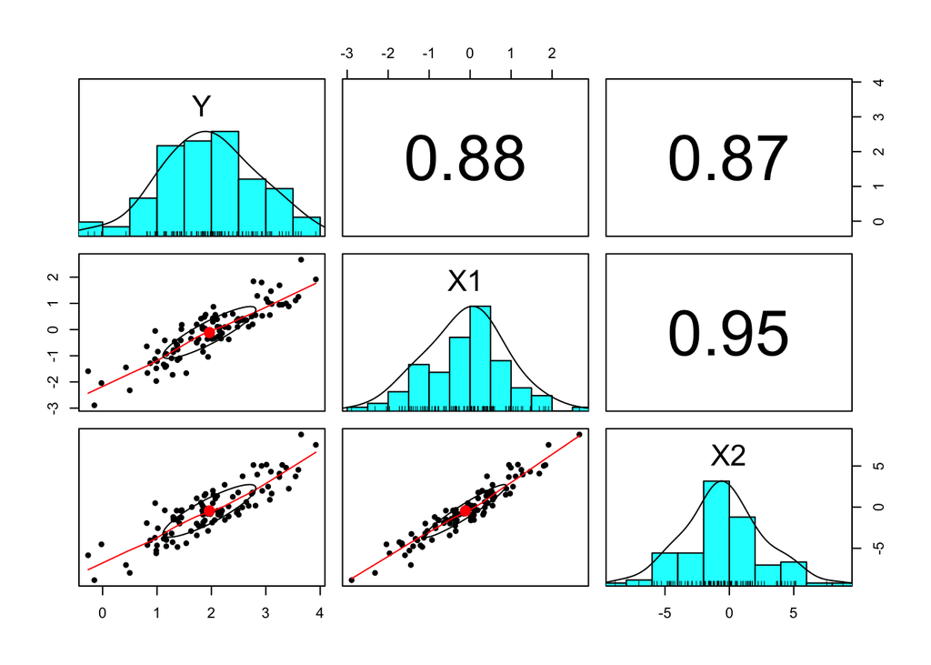

```r
sim_dat<-cbind(Y,X1,X2)
pairs.panels(sim_dat)
```

```r
vif(lm1)
```

```
##       X1       X2
## 10.60404 10.60404
```

```r
pander::pander(head(sim_dat), caption = "Tabla de datos")
```

Tabla de datos

| Y | X1 | X2 |
| --- | --- | --- |
| 2.811 | 0.5497 | 0.1796 |
| 1.015 | -0.8416 | -2.566 |
| 1.836 | 0.033 | 0.1865 |
| 2.934 | 0.5241 | 1.979 |
| 1.287 | -1.728 | -4.251 |
| 1.978 | -0.2779 | -0.857 |

```r
pander::pander(vif(lm1), caption = "VIF")
```

| X1 | X2 |
| --- | --- |
| 10.6 | 10.6 |

```r
# Normalidad
shapiro.test (residuals (lm1))
```

```
##
##  Shapiro-Wilk normality test
##
## data:  residuals(lm1)
## W = 0.97672, p-value = 0.07363
```

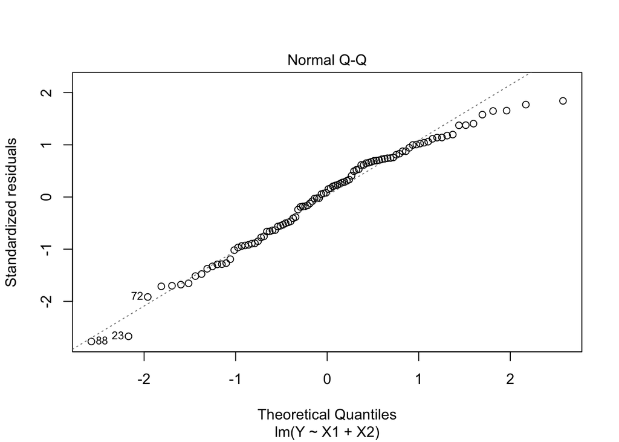

```r
plot(lm1, which = 2)
```

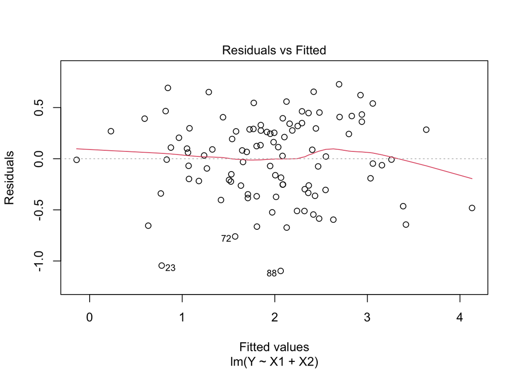

```r
# Homogeneidad de varianzas usando plot
plot(lm1, which = 1)
```

```r
# Comparación usando residuales
res <- anova(lm1, lm2)
pander::pander(res, caption = "Comparación modelos usando residuales")
```

Comparación modelos usando residuales

| Res.Df | RSS | Df | Sum of Sq | F | Pr(>F) |
| --- | --- | --- | --- | --- | --- |
| 97 | 15.48 | NA | NA | NA | NA |
| 98 | 15.99 | -1 | -0.5101 | 3.196 | 0.07692 |

```r
# Comparación usando AIC
aic <- AIC(lm1, lm2)

pander::pander(aic, caption = "Comparación modelos usando AIC")
```

Comparación modelos usando AIC

|  | df | AIC |
| --- | --- | --- |
| **lm1** | 4 | 105.2 |
| **lm2** | 3 | 106.5 |

```r
# Comparación usando BIC
bic <- BIC(lm1, lm2)

pander::pander(bic, caption = "Comparación modelos usando BIC")
```

Comparación modelos usando BIC

|  | df | BIC |
| --- | --- | --- |
| **lm1** | 4 | 115.6 |
| **lm2** | 3 | 114.3 |

## Regresión lineal múltiple: ejercicio guía.

```r
set.seed(123)
# Simulated Correlation between two QT
n <- 100 # number of individuals
means   <- c(50, 10) # salmon weight and fillet color
cov.mat <- matrix(c(4, 3.35, 3.5, 3), nrow = 2, ncol = 2) # variance-covariance matrix
pred_1.predic_2 <- data.frame(mvrnorm(n, means, cov.mat))
names(pred_1.predic_2) <- c("pred_1", 'pred_2')
pred_1.predic_2[1:10, ]
```

```
##      pred_1    pred_2
## 1  50.95836 11.141044
## 2  50.51392 10.328970
## 3  46.84728  7.392332
## 4  49.78360  9.967657
## 5  49.53425 10.020700
## 6  46.58069  7.073127
## 7  48.91156  9.410107
## 8  52.14900 12.591883
## 9  51.28202 11.273524
## 10 51.08753 10.529630
```

```r
# Look at the mean and covariance to check the function
colMeans(pred_1.predic_2)
```

```
##    pred_1    pred_2
## 49.796689  9.872485
```

```r
cov(pred_1.predic_2)
```

```
##          pred_1   pred_2
## pred_1 3.375960 2.779954
## pred_2 2.779954 2.468166
```

```r
cor(pred_1.predic_2$pred_1, pred_1.predic_2$pred_2)
```

```
## [1] 0.9630566
```

```r
x =data.frame(matrix(rnorm(2*100),ncol=2))
x <- cbind(x,pred_1.predic_2$pred_1,pred_1.predic_2$pred_2)
names(x)<-c('Pred_X1','Pred_X2','Pred_X3',"Pred_X4")

beta<-c(-4,4,0.2,4) # these are the regression coefficients

trait_y <- as.matrix(x)%*%beta + rnorm(nrow(x),0,1)

aqua_dat <- cbind(trait_y,x)

l<-lm(trait_y~Pred_X1+Pred_X2+Pred_X3+Pred_X4,data=x)

summary(l)
```

```
##
## Call:
## lm(formula = trait_y ~ Pred_X1 + Pred_X2 + Pred_X3 + Pred_X4,
##     data = x)
##
## Residuals:
##      Min       1Q   Median       3Q      Max
## -2.47336 -0.58010  0.07461  0.68778  2.46552
##
## Coefficients:
##             Estimate Std. Error t value Pr(>|t|)
## (Intercept)  6.87946    7.74164   0.889    0.376
## Pred_X1     -4.05046    0.10468 -38.695   <2e-16 ***
## Pred_X2      3.97667    0.09506  41.832   <2e-16 ***
## Pred_X3     -0.01023    0.19938  -0.051    0.959
## Pred_X4      4.37483    0.23283  18.790   <2e-16 ***
## ---
## Signif. codes:  0 '***' 0.001 '**' 0.01 '*' 0.05 '.' 0.1 ' ' 1
##
## Residual standard error: 0.9794 on 95 degrees of freedom
## Multiple R-squared:  0.988,  Adjusted R-squared:  0.9875
## F-statistic:  1957 on 4 and 95 DF,  p-value: < 2.2e-16
```

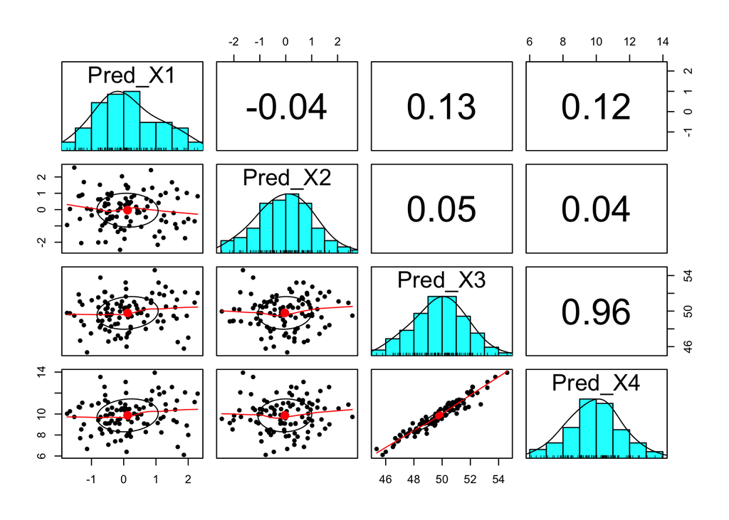

```r
pairs.panels(x[1:4])
```

```r
vif(l)
```

```
##   Pred_X1   Pred_X2   Pred_X3   Pred_X4
##  1.020348  1.006429 13.851503 13.808926
```

```r
# Exporta datos simulados aqua_dat
# a) Guarda el directorio actual
old_wd <- getwd()

# b) Va al directorio Datos_simulados
setwd(paste0(getwd(),"/Datos_simulados"))

write.table(aqua_dat, file = "aqua_dat.csv", sep = ";", dec = ",")

# c) Vuele al directorio principal
setwd(old_wd)
```